# Energy prediction - original file to be translated

16 06 2023

The environment and console is cleared to perform regression algorithms.

```r
gc()
```

```
##          used (Mb) gc trigger (Mb) max used (Mb)
## Ncells 501416 26.8    1110514 59.4   644205 34.5
## Vcells 885769  6.8    8388608 64.0  1635208 12.5
```

```r
rm(list = ls())
```

The Energy dataset consists of energy use in Watt-hours in a house denoted every 10 minutes. The period of measurement lasted 4,5 months.

The main attributes are: - The temperature in every room of a house - Humidity in every room of a house - Temperature outside - Humidity outside - Pressure - Wind speed - Visibility - 2 random variables - Time

The necessary libraries are loaded.

First load the data

```r
data <- read_csv("../data/energydata_complete.csv")
```

Exploratory data analysis I’m Checking whether any missing values are present in the dataset

```r
print(sum(is.na(data)))
```

```
## [1] 0
```

As per printed code, there are no missing values.

The dataset is summarized

```r
summary(data)
```

```
##       date                       Appliances          lights
##  Min.   :2016-01-11 17:00:00   Min.   :  10.00   Min.   : 0.000
##  1st Qu.:2016-02-14 23:15:00   1st Qu.:  50.00   1st Qu.: 0.000
##  Median :2016-03-20 05:30:00   Median :  60.00   Median : 0.000
##  Mean   :2016-03-20 05:30:00   Mean   :  97.69   Mean   : 3.802
##  3rd Qu.:2016-04-23 11:45:00   3rd Qu.: 100.00   3rd Qu.: 0.000
##  Max.   :2016-05-27 18:00:00   Max.   :1080.00   Max.   :70.000
##        T1             RH_1             T2             RH_2
##  Min.   :16.79   Min.   :27.02   Min.   :16.10   Min.   :20.46
##  1st Qu.:20.76   1st Qu.:37.33   1st Qu.:18.79   1st Qu.:37.90
##  Median :21.60   Median :39.66   Median :20.00   Median :40.50
##  Mean   :21.69   Mean   :40.26   Mean   :20.34   Mean   :40.42
##  3rd Qu.:22.60   3rd Qu.:43.07   3rd Qu.:21.50   3rd Qu.:43.26
##  Max.   :26.26   Max.   :63.36   Max.   :29.86   Max.   :56.03
##        T3             RH_3             T4             RH_4
##  Min.   :17.20   Min.   :28.77   Min.   :15.10   Min.   :27.66
##  1st Qu.:20.79   1st Qu.:36.90   1st Qu.:19.53   1st Qu.:35.53
##  Median :22.10   Median :38.53   Median :20.67   Median :38.40
##  Mean   :22.27   Mean   :39.24   Mean   :20.86   Mean   :39.03
##  3rd Qu.:23.29   3rd Qu.:41.76   3rd Qu.:22.10   3rd Qu.:42.16
##  Max.   :29.24   Max.   :50.16   Max.   :26.20   Max.   :51.09
##        T5             RH_5             T6              RH_6
##  Min.   :15.33   Min.   :29.82   Min.   :-6.065   Min.   : 1.00
##  1st Qu.:18.28   1st Qu.:45.40   1st Qu.: 3.627   1st Qu.:30.02
##  Median :19.39   Median :49.09   Median : 7.300   Median :55.29
##  Mean   :19.59   Mean   :50.95   Mean   : 7.911   Mean   :54.61
##  3rd Qu.:20.62   3rd Qu.:53.66   3rd Qu.:11.256   3rd Qu.:83.23
##  Max.   :25.80   Max.   :96.32   Max.   :28.290   Max.   :99.90
##        T7             RH_7             T8             RH_8
##  Min.   :15.39   Min.   :23.20   Min.   :16.31   Min.   :29.60
##  1st Qu.:18.70   1st Qu.:31.50   1st Qu.:20.79   1st Qu.:39.07
##  Median :20.03   Median :34.86   Median :22.10   Median :42.38
##  Mean   :20.27   Mean   :35.39   Mean   :22.03   Mean   :42.94
##  3rd Qu.:21.60   3rd Qu.:39.00   3rd Qu.:23.39   3rd Qu.:46.54
##  Max.   :26.00   Max.   :51.40   Max.   :27.23   Max.   :58.78
##        T9             RH_9           T_out         Press_mm_hg
##  Min.   :14.89   Min.   :29.17   Min.   :-5.000   Min.   :729.3
##  1st Qu.:18.00   1st Qu.:38.50   1st Qu.: 3.667   1st Qu.:750.9
##  Median :19.39   Median :40.90   Median : 6.917   Median :756.1
##  Mean   :19.49   Mean   :41.55   Mean   : 7.412   Mean   :755.5
##  3rd Qu.:20.60   3rd Qu.:44.34   3rd Qu.:10.408   3rd Qu.:760.9
##  Max.   :24.50   Max.   :53.33   Max.   :26.100   Max.   :772.3
##      RH_out         Windspeed        Visibility      Tdewpoint
##  Min.   : 24.00   Min.   : 0.000   Min.   : 1.00   Min.   :-6.600
##  1st Qu.: 70.33   1st Qu.: 2.000   1st Qu.:29.00   1st Qu.: 0.900
##  Median : 83.67   Median : 3.667   Median :40.00   Median : 3.433
##  Mean   : 79.75   Mean   : 4.040   Mean   :38.33   Mean   : 3.761
##  3rd Qu.: 91.67   3rd Qu.: 5.500   3rd Qu.:40.00   3rd Qu.: 6.567
##  Max.   :100.00   Max.   :14.000   Max.   :66.00   Max.   :15.500
##       rv1                rv2
##  Min.   : 0.00532   Min.   : 0.00532
##  1st Qu.:12.49789   1st Qu.:12.49789
##  Median :24.89765   Median :24.89765
##  Mean   :24.98803   Mean   :24.98803
##  3rd Qu.:37.58377   3rd Qu.:37.58377
##  Max.   :49.99653   Max.   :49.99653
```

I am checking the data types of each column.

```r
sapply(data, class)
```

```
## $date
## [1] "POSIXct" "POSIXt"
##
## $Appliances
## [1] "numeric"
##
## $lights
## [1] "numeric"
##
## $T1
## [1] "numeric"
##
## $RH_1
## [1] "numeric"
##
## $T2
## [1] "numeric"
##
## $RH_2
## [1] "numeric"
##
## $T3
## [1] "numeric"
##
## $RH_3
## [1] "numeric"
##
## $T4
## [1] "numeric"
##
## $RH_4
## [1] "numeric"
##
## $T5
## [1] "numeric"
##
## $RH_5
## [1] "numeric"
##
## $T6
```

[output cut: 31 more lines]

```
##
## $Windspeed
## [1] "numeric"
##
## $Visibility
## [1] "numeric"
##
## $Tdewpoint
## [1] "numeric"
##
## $rv1
## [1] "numeric"
##
## $rv2
## [1] "numeric"
```

All variables except of the date are numeric. The only column which might be transformed is time as it might be broken down into diverse time intervals. Therefore, the year, month, day, hour, minute, and second variables are extracted.

```r
data$year <- year(data$date)
data$month <- month(data$date)
data$day <- day(data$date)
data$hour <- hour(data$date)
data$minute <- minute(data$date)
data$second <- second(data$date)
```

The new variable is created indicating the day of the week, hour of the day and time of the day (morning,afternoon or evening).

```r
data$day_of_week <- wday(data$date, label = TRUE)
data$hour_of_day <- hour(data$date)
data$time_of_day <- ifelse(data$hour_of_day >= 6 & data$hour_of_day < 12, "morning",
                           ifelse(data$hour_of_day >= 12 & data$hour_of_day < 18, "afternoon", "evening"))
```

```r
numeric_columns <- which(sapply(data, is.numeric))
data_numeric <- data[, numeric_columns]
```

The date variable is removed from the dataset as other time related variables were added recently. The Random Variable 1 and 2 are removed as the author of the dataset added it on purpose to make additional noise of data.

```r
data_numeric <- dplyr::select(data_numeric, -second, -year, -hour_of_day, -rv1, -rv2)
```

The regression model was created with all variables to check if the multicollinearity is present.

```r
model_all <- lm(Appliances ~ ., data=data_numeric)
summary(model_all)
```

```
##
## Call:
## lm(formula = Appliances ~ ., data = data_numeric)
##
## Residuals:
##     Min      1Q  Median      3Q     Max
## -242.55  -43.30  -18.99    6.84  928.99
##
## Coefficients:
##              Estimate Std. Error t value Pr(>|t|)
## (Intercept) -19.73213   95.54215  -0.207 0.836381
## lights        1.90291    0.09588  19.848  < 2e-16 ***
## T1           -3.37656    1.86110  -1.814 0.069650 .
## RH_1         14.55297    0.67420  21.586  < 2e-16 ***
## T2          -18.07949    1.63346 -11.068  < 2e-16 ***
## RH_2        -13.23446    0.76592 -17.279  < 2e-16 ***
## T3           27.13070    1.08865  24.921  < 2e-16 ***
## RH_3          4.16974    0.68627   6.076 1.26e-09 ***
## T4           -3.10999    1.02291  -3.040 0.002366 **
## RH_4         -1.27381    0.64657  -1.970 0.048839 *
## T5            0.16124    1.17703   0.137 0.891037
## RH_5          0.05161    0.08731   0.591 0.554491
## T6            7.03208    0.64133  10.965  < 2e-16 ***
## RH_6          0.06656    0.07707   0.864 0.387814
## T7            0.77729    1.33399   0.583 0.560112
## RH_7         -1.48040    0.42938  -3.448 0.000566 ***
## T8            7.61415    0.97203   7.833 4.99e-15 ***
## RH_8         -3.68843    0.39189  -9.412  < 2e-16 ***
## T9           -9.75645    1.88243  -5.183 2.21e-07 ***
## RH_9         -0.53305    0.43598  -1.223 0.221472
## T_out        -7.80519    1.56170  -4.998 5.85e-07 ***
## Press_mm_hg   0.14475    0.10889   1.329 0.183759
## RH_out       -0.33449    0.32539  -1.028 0.303972
## Windspeed     1.47015    0.34853   4.218 2.47e-05 ***
## Visibility    0.13985    0.05764   2.426 0.015256 *
## Tdewpoint     2.96959    1.48903   1.994 0.046132 *
## month       -11.94314    2.01463  -5.928 3.11e-09 ***
## day          -0.11538    0.09909  -1.164 0.244268
## hour          0.95772    0.14033   6.825 9.05e-12 ***
## minute        0.08322    0.03898   2.135 0.032795 *
## ---
## Signif. codes:  0 '***' 0.001 '**' 0.01 '*' 0.05 '.' 0.1 ' ' 1
##
## Residual standard error: 93.52 on 19705 degrees of freedom
## Multiple R-squared:  0.1691, Adjusted R-squared:  0.1679
## F-statistic: 138.3 on 29 and 19705 DF,  p-value: < 2.2e-16
```

```r
vif(model_all)
```

```
##      lights          T1        RH_1          T2        RH_2          T3
##    1.306151   20.157571   16.239051   28.950386   21.922244   10.761062
##        RH_3          T4        RH_4          T5        RH_5          T6
##   11.255109    9.852158   17.776217   10.635512    1.400071   34.421045
##        RH_6          T7        RH_7          T8        RH_8          T9
##   13.003826   17.874636   10.879662    8.157152    9.457181   32.451651
##        RH_9       T_out Press_mm_hg      RH_out   Windspeed  Visibility
##    7.391118  155.584656    1.464730   53.041107    1.646702    1.042662
##   Tdewpoint       month         day        hour      minute
##   88.017902   16.422992    1.582012    2.128709    1.000049
```

As per shown Variance Inflated factor, there are a lot of variables which are correlated to each other (the VIF exceeds 4 treshold). Therefore I remove iteratively variables with high VIF and check again if the model consists highly correlated variables.

The minute variable is almost uncorrelated with other variables, hence the it will be removed from the dataset as well.

```r
# T4 removed
data_numeric <- dplyr::select(data_numeric, -T4)
model_all <- lm(Appliances ~ ., data=data_numeric)
vif(model_all)
```

[output not shown]

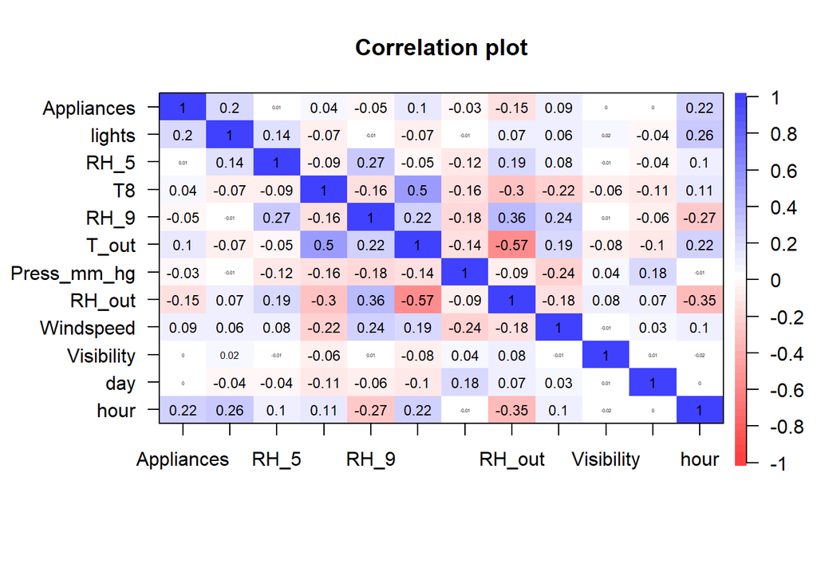

```r
corPlot(data_numeric, cex = 0.5, margin = c(4,4,4,4))
```

The above plot shows that the variables are correlated to the moderate level at most.

It turns out that there is no need to keep date, day of week and time of day variables.

```r
data <- dplyr::select(data, -date)
data <- dplyr::select(data, -day_of_week)
data <- dplyr::select(data, -time_of_day)

# Create a vector of predictors
predictors <- names(data_numeric)
predictors <- predictors[predictors != "Appliances"]
```

The independent variables are standardized to avoid biased results of predictions.

```r
# Subset the data to include only the predictors
subset_data <- data_numeric[, predictors]

# Standardize the predictors
subset_data <- scale(subset_data)

# Re-combine the standardized predictors with the "Appliances" variable
data_numeric[, predictors] <- subset_data
```

The dataset is divided into training and test set with ratio 80/20.

```r
set.seed(123)
data <- data_numeric
# split the data into training and testing data
train_indices <- sample(1:nrow(data), 0.8*nrow(data))
train_data <- data[train_indices, ]
test_data <- data[-train_indices, ]
# Define the predictor variables
predictors <- names(data)[-c(1,2)]
response <- "Appliances"
```

Both sets are converted into DMatrix

```r
dtrain <- xgb.DMatrix(data = as.matrix(train_data[predictors]), label = unlist(train_data[response]))
dtest <- xgb.DMatrix(data = as.matrix(test_data[predictors]))
```

The XGBoost model is trained. After many trials with hyperparameter tuning, the following parameters were chosen: lambda = 0.8 alpha =0.9 nrounds = 100 colsample_bytree = 0.6 gamma=0.85 eta = 0.036 max_depth = 25, min_child_weight = 1, subsample=0.8, num_parallel_tree = 4 early_stopping_rounds = 50

The most significant hyperparameters was eta and number of parallel trees.

The predictions on test data and MAPE are generated.

```r
# Make predictions on the test data
predictions <- predict(xgb_model, newdata = dtest)

# Extract the response variable from the test data as a vector
test_response <- unlist(test_data[response])

# Calculate the absolute percentage error
ape <- abs((test_response - predictions) / test_response)

# Calculate the mean absolute percentage error
MAPE <- mean(ape) * 100

# Print the result
print(MAPE)
```

```
## [1] 24.43461
```

The Result is MAPE: 24 percent.

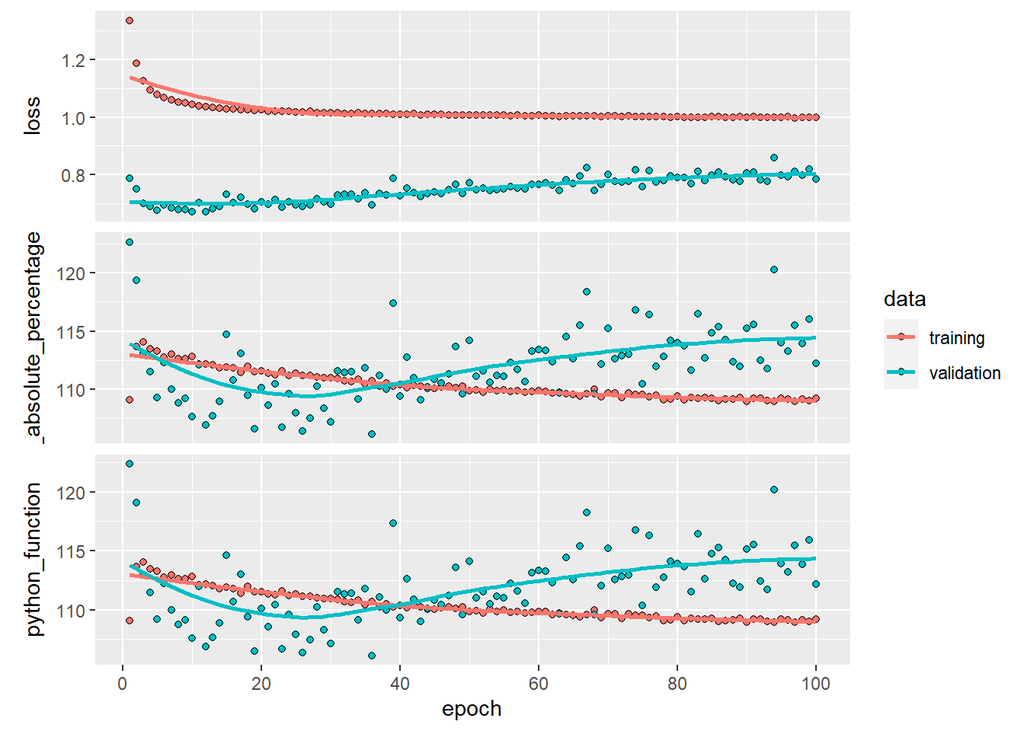

```r
# Preprocess the data




data_train <- data[1:round(0.7*nrow(data)),]
data_test <- data[(round(0.7*nrow(data))+1):nrow(data),]
x_train <- as.matrix(data_train[,-c(1,2)])
y_train <- as.matrix(data_train[,2])
x_test <- as.matrix(data_test[,-c(1,2)])
y_test <- as.matrix(data_test[,2])

# Build the model with L2 regularization
model <- keras_model_sequential() %>%
  layer_dense(units = 16, activation = "relu", input_shape = ncol(x_train),
              kernel_regularizer = regularizer_l2(0.01)) %>%
  layer_dense(units = 4, activation = "relu", kernel_regularizer = regularizer_l2(0.01)) %>%
  layer_dense(units = 2, activation = "relu", kernel_regularizer = regularizer_l2(0.01)) %>%
  layer_dense(units = 1, activation = "relu", kernel_regularizer = regularizer_l2(0.01))

# Define a function to calculate MAPE
mape <- function(y_true, y_pred) {
  return(mean(abs((y_true - y_pred) / y_true)) * 100)
}

# Compile the model with MAPE as a metric
model %>% compile(loss = "mean_squared_error", optimizer = "adam",
                  metrics = c("mean_absolute_percentage_error", mape))

# Fit the model and evaluate its performance
history <- model %>% fit(x_train, y_train, epochs = 100, batch_size = 32,
                         validation_data = list(x_test, y_test))
```

Sources: Appliances energy prediction Data Set: https://archive.ics.uci.edu/ml/datasets/Appliances+energy+prediction